# Final Project Presentation

11/29/2023

## Crime Statistics Data Set

- In this project, I processed a data set of 2022 crime statistics for the City of Houston. The data set is posted on the City of Houston Official website.
- The NIBRS Data is updated monthly in one aggregated Excel spreadsheet; NIBRS stands for National Incident-Based Reporting System.
- The data on the Excel spreadsheet only shows the police calls that resulted in filing a report. Keep in mind that most police calls don’t warrant a police report, for example, alarm calls, traffic stops, trespassers, and disturbances.
- This data does not account for unreported crimes in the City of Houston.
- The data shows incident numbers and is organized by zip codes, police districts, and beats, as well as street and block numbers.

## Data dictionary

- the data contains 249912 rows and 16 variables.
- Occurrence Date: date of the incident.
- Occurrence Hour: hour when the incident occurred, recorded in military time.
- NIBRS Description: offense type.
- Offense Count: number of offenses committed.
- Beat: beat where the incident occurred.
- Premise : location type where the incident occurred.
- Block Range: street block number where the incident occurred.
- Street Name: street name where the incident occurred.
- Street Type: street type (Dr, St, Ave)
- Suffix [Streets]: N, S, W, E.

## Glimpse of Dataset

```
## Rows: 249,912
## Columns: 16
## $ Incident          <dbl> 10322, 10322, 11622, 15122, 15122, 16022, 16022, 180…
## $ RMSOccurrenceDate <dttm> 2022-01-01, 2022-01-01, 2022-01-01, 2022-01-01, 202…
## $ RMSOccurrenceHour <dbl> 0, 0, 0, 0, 0, 0, 0, 0, 0, 0, 0, 0, 0, 0, 0, 0, 0, 0…
## $ NIBRSClass        <chr> "90C", "520", "290", "290", "520", "520", "290", "22…
## $ NIBRSDescription  <chr> "Disorderly conduct", "Weapon law violations", "Dest…
## $ OffenseCount      <dbl> 1, 1, 1, 1, 1, 1, 1, 1, 1, 1, 1, 1, 1, 1, 1, 1, 1, 1…
## $ Beat              <chr> "3B10", "3B10", "8C20", "11H10", "11H10", "12D30", "…
## $ Premise           <chr> "Residence, Home (Includes Apartment)", "Residence, …
## $ StreetNo          <chr> "5500", "5500", "7100", "6540", "6540", "9031", "903…
## $ StreetName        <chr> "ANTOINE", "ANTOINE", "LEY", "AVENUE J", "AVENUE J",…
## $ StreetType        <chr> "DR", "DR", "RD", NA, NA, "DR", "DR", "ST", "LN", "S…
## $ Suffix            <chr> NA, NA, NA, NA, NA, NA, NA, NA, NA, NA, NA, NA, NA, …
## $ City              <chr> "HOUSTON", "HOUSTON", "HOUSTON", "HOUSTON", "HOUSTON…
## $ ZIPCode           <dbl> 77091, 77091, 77028, 77011, 77011, 77034, 77034, 770…
## $ MapLongitude      <dbl> -95.47323, -95.47323, -95.30201, -95.30826, -95.3082…
## $ MapLatitude       <dbl> 29.84436, 29.84436, 29.83137, 29.74446, 29.74446, 29…
```

## Zip Code Summary

- The minimum Zip Code 36830 is outside the range of Zip Codes in Houston.
- For the Zip Code plots I input the right Zip Codes for the city of Houston to avoid bad data.
- I plotted incidents per Zip Codes on three different plots so it is easier to read.

```
##    Min. 1st Qu.  Median    Mean 3rd Qu.    Max.    NA's
##   36830   77022   77047   77060   77076   77876    3235
```

## Number of incidents per Zip Codes (77002 to 77036)

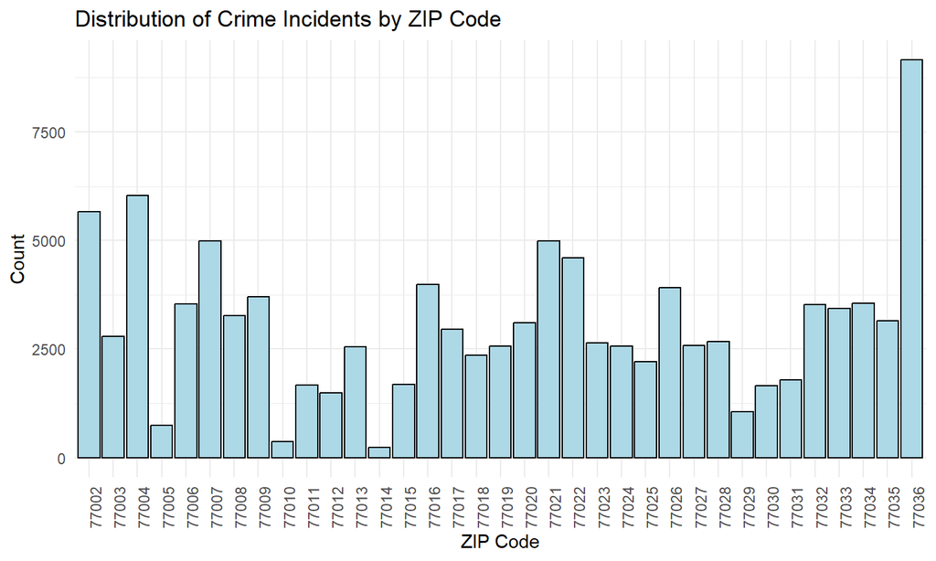

## Number of incidents per Zip Codes (77037 to 77071)

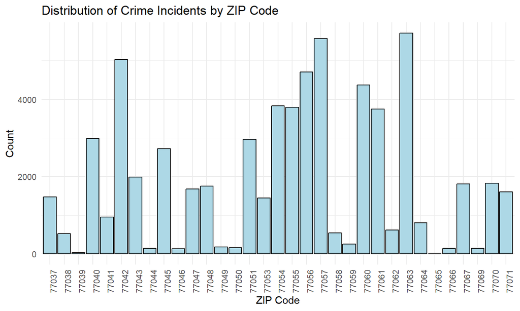

## Number of incidents per Zip Codes (77072 to 77099)

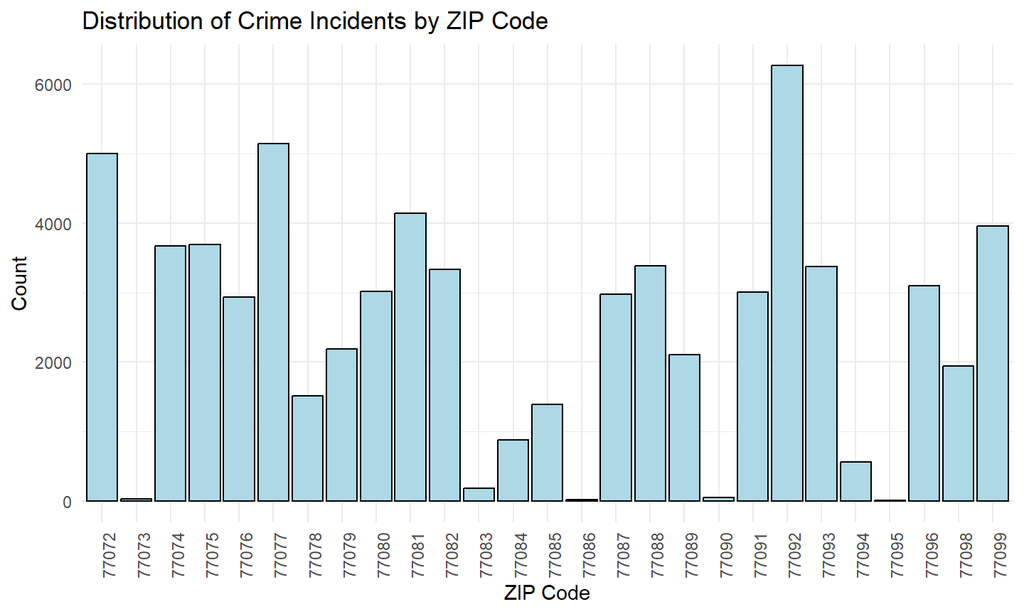

## Zip Codes with highest incidents

```
## # A tibble: 10 × 2
##    ZIPCode Count
##      <dbl> <int>
##  1   77036  9151
##  2   77092  6265
##  3   77004  6034
##  4   77063  5708
##  5   77002  5658
##  6   77057  5567
##  7   77077  5144
##  8   77042  5032
##  9   77072  4999
## 10   77021  4994
```

## Number of reported incidents per month

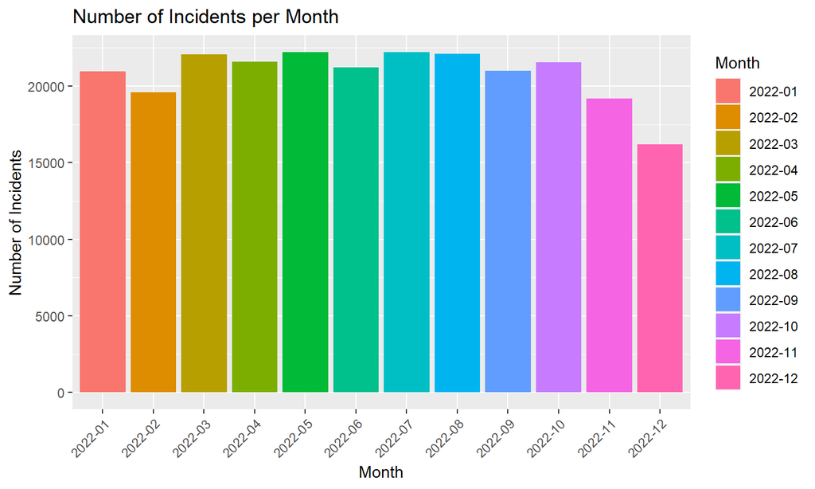

## Most Committed Crimes in Houston

```
## # A tibble: 10 × 2
##    NIBRSDescription                          Count
##    <chr>                                     <int>
##  1 Theft from motor vehicle                  26165
##  2 Simple assault                            23173
##  3 Destruction, damage, vandalism            20620
##  4 Intimidation                              18682
##  5 All other larceny                         18045
##  6 Motor vehicle theft                       17123
##  7 Theft of motor vehicle parts or accessory 15771
##  8 All other offenses                        15063
##  9 Aggravated Assault                        14826
## 10 Burglary, Breaking and Entering           14063
```

## Least Committed Crimes in Houston

```
## # A tibble: 10 × 2
##    NIBRSDescription                        Count
##    <chr>                                   <int>
##  1 Bad checks                                 16
##  2 Sexual assault with an object              10
##  3 Human Trafficking/Involuntary Servitude     7
##  4 Justifiable homicide                        7
##  5 Bribery                                     6
##  6 Peeping tom                                 5
##  7 Statutory rape                              5
##  8 Negligent manslaughter                      4
##  9 Promoting gambling                          3
## 10 Betting/wagering                            1
```

## Most committed crimes by Zip Codes

```
## # A tibble: 174 × 3
## # Groups:   ZIPCode [174]
##    NIBRSDescription          ZIPCode Count
##    <chr>                       <dbl> <int>
##  1 Drug, narcotic violations   36830     1
##  2 Drug, narcotic violations   46168     1
##  3 Theft from motor vehicle    77002   950
##  4 Theft from motor vehicle    77003   717
##  5 Theft from motor vehicle    77004   955
##  6 Theft from motor vehicle    77005   183
##  7 Theft from motor vehicle    77006   851
##  8 Theft from motor vehicle    77007  1066
##  9 Theft from motor vehicle    77008   693
## 10 All other larceny           77009   355
## # ℹ 164 more rows
```

## Beats and Districts

-Police departments don’t respond to calls by zip codes; they respond to calls by districts and beats.

-The city is divided into districts, and each district is further divided into beats.

-A beat is the area that is being patrolled.Districts are divided among police stations throughout the city.

-A PDF file of districts and beats was obtained from the City of Houston website.

-The next slide displays the City of Houston map per district and beat.

-I patrolled 18 districts from 2018 until 2021.I investigate robbery cases in districts 1, 2, 9, 10, and 17

```
## Using poppler version 23.08.0
```

```
## Converting page 1 to hpd_beat_map_1.png... done!
```

[figure not shown]

## Districts and Beats map

[figure not shown]

## Beats with the highest incidents

```
## # A tibble: 10 × 2
##    Beat  Count
##    <chr> <int>
##  1 12D10  5418
##  2 3B10   5273
##  3 15E40  5228
##  4 18F40  5075
##  5 22B20  5012
##  6 17E10  4973
##  7 19G10  4820
##  8 14D20  4779
##  9 18F20  4718
## 10 1A20   4593
```

## Incidents per district

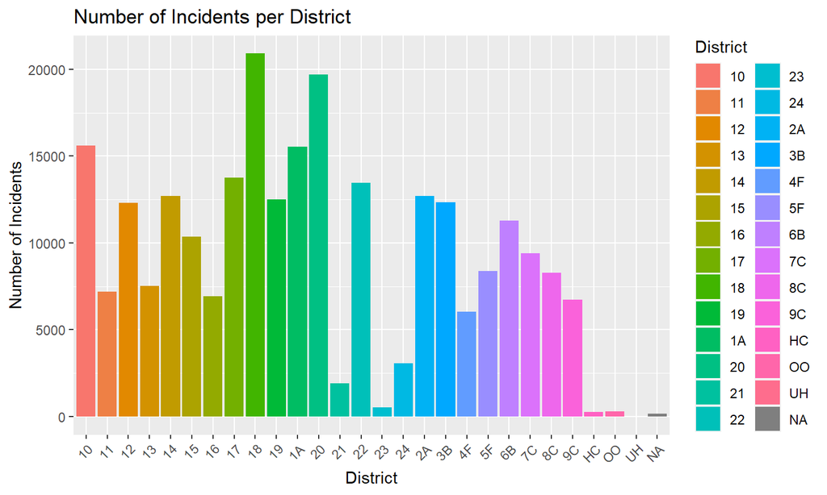

## Districts with the highest incidents

```
## # A tibble: 10 × 2
##    District IncidentCount
##    <chr>            <int>
##  1 18               20901
##  2 20               19702
##  3 10               15591
##  4 1A               15553
##  5 17               13767
##  6 22               13473
##  7 14               12717
##  8 2A               12704
##  9 19               12494
## 10 3B               12327
```

## Districts with the lowest incidents

```
## # A tibble: 10 × 2
##    District IncidentCount
##    <chr>            <int>
##  1 16                6915
##  2 9C                6743
##  3 4F                6050
##  4 24                3071
##  5 21                1920
##  6 23                 521
##  7 OO                 299
##  8 HC                 274
##  9 <NA>               164
## 10 UH                   1
```

## 2022 Murder Count

```
## # A tibble: 1 × 1
##   Count
##   <int>
## 1   411
```

## Zip Codes with the highest murder rate

```
## # A tibble: 84 × 2
##    ZIPCode MurderCount
##      <dbl>       <int>
##  1   77036          21
##  2   77021          14
##  3   77004          13
##  4   77033          13
##  5   77087          11
##  6   77034          10
##  7   77042          10
##  8   77099          10
##  9   77009           9
## 10   77016           9
## # ℹ 74 more rows
```

## Zip Codes with the lowest murder rate

```
## # A tibble: 10 × 2
##    ZIPCode MurderCount
##      <dbl>       <int>
##  1   77049           1
##  2   77091           1
##  3   77094           1
##  4   77098           1
##  5   77339           1
##  6   77345           1
##  7   77396           1
##  8   77489           1
##  9   77502           1
## 10   77598           1
```

## Murder rate plot by Zip Codes (77002 to 77036)

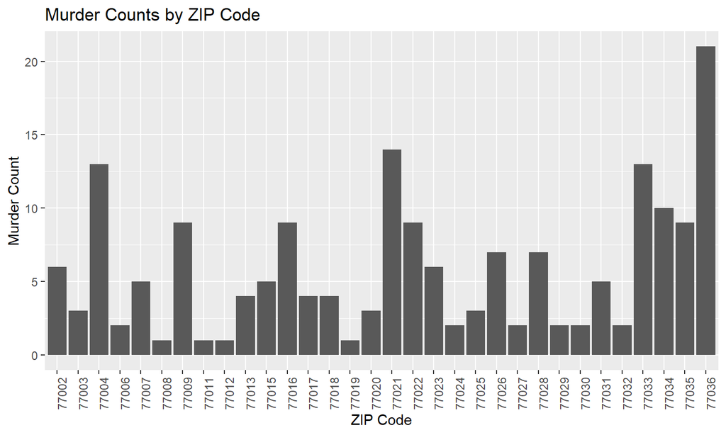

## Murder rate plot by Zip Codes (77037 to 77071)

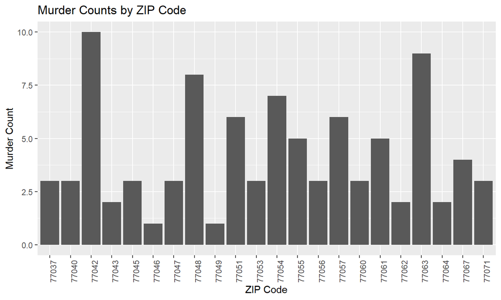

## Murder rate plot by Zip Codes (77072 to 77099)

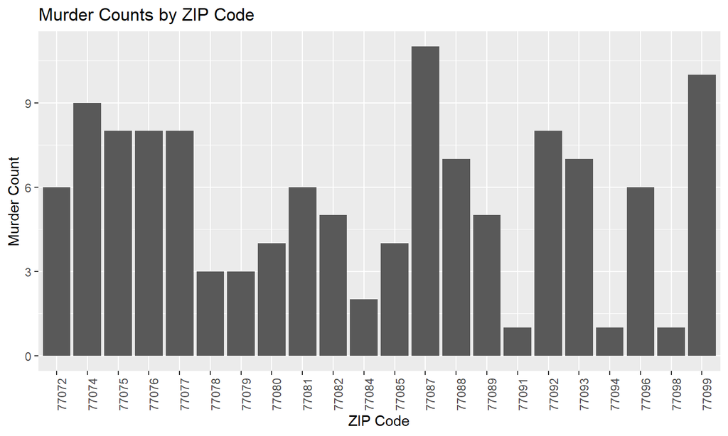

## Murder distribution per month

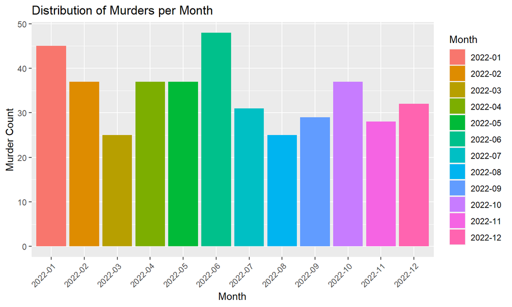

## Murder distribution per district

```
## # A tibble: 23 × 2
##    District IncidentCount
##    <chr>            <int>
##  1 14                  41
##  2 17                  31
##  3 20                  30
##  4 19                  28
##  5 18                  27
##  6 10                  24
##  7 12                  21
##  8 13                  21
##  9 6B                  20
## 10 15                  18
## # ℹ 13 more rows
```

## Murder rate per district plot

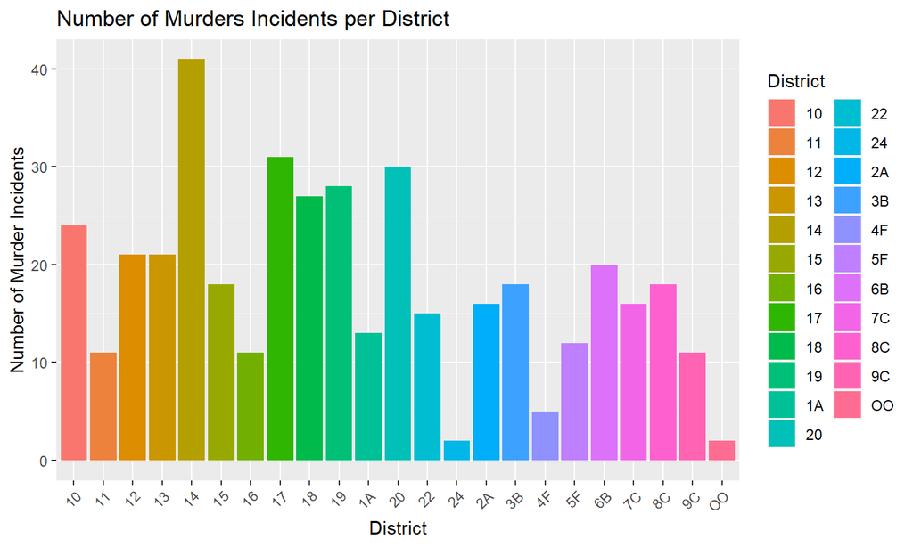

## 2022 Robberies

```
## # A tibble: 1 × 1
##   Count
##   <int>
## 1  7107
```

## Zip Codes with the highest robberies

```
## # A tibble: 10 × 2
##    ZIPCode IncidentCount
##      <dbl>         <int>
##  1   77036           475
##  2   77057           221
##  3   77081           196
##  4   77072           184
##  5   77092           182
##  6   77063           180
##  7   77002           167
##  8   77004           165
##  9   77022           157
## 10   77074           155
```

## Zip Codes with the lowest robberies

```
## # A tibble: 10 × 2
##    ZIPCode IncidentCount
##      <dbl>         <int>
##  1   77336             2
##  2   77046             1
##  3   77069             1
##  4   77086             1
##  5   77208             1
##  6   77401             1
##  7   77494             1
##  8   77571             1
##  9   77584             1
## 10   77587             1
```

## Beats with the highest robberies

```
## # A tibble: 10 × 2
##    Beat  IncidentCount
##    <chr>         <int>
##  1 19G10           265
##  2 17E10           235
##  3 12D10           199
##  4 18F30           194
##  5 14D20           174
##  6 20G10           165
##  7 3B10            161
##  8 22B20           159
##  9 13D20           158
## 10 17E40           154
```

## Beats with the lowest robberies

```
## # A tibble: 10 × 2
##    Beat   IncidentCount
##    <chr>          <int>
##  1 13D30              4
##  2 18F10              4
##  3 1A40               4
##  4 24C60              3
##  5 24C40              2
##  6 21I50              1
##  7 23J50              1
##  8 24C10              1
##  9 HCC1               1
## 10 UH-3PD             1
```

## Robberies distribution per month

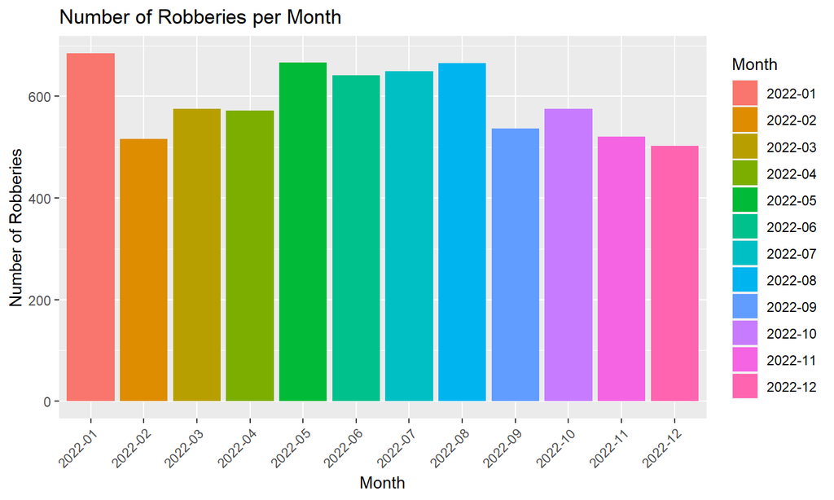

## Districts with the highest robberies

```
## # A tibble: 27 × 2
##    District IncidentCount
##    <chr>            <int>
##  1 18                 651
##  2 17                 562
##  3 19                 534
##  4 20                 527
##  5 14                 428
##  6 10                 423
##  7 6B                 378
##  8 3B                 372
##  9 22                 348
## 10 7C                 319
## # ℹ 17 more rows
```

## Districts with the lowest robberies

```
## # A tibble: 10 × 2
##    District IncidentCount
##    <chr>            <int>
##  1 16                 209
##  2 8C                 197
##  3 9C                 184
##  4 4F                 108
##  5 24                  19
##  6 HC                   7
##  7 OO                   7
##  8 21                   1
##  9 23                   1
## 10 UH                   1
```

## Robberies per district plot

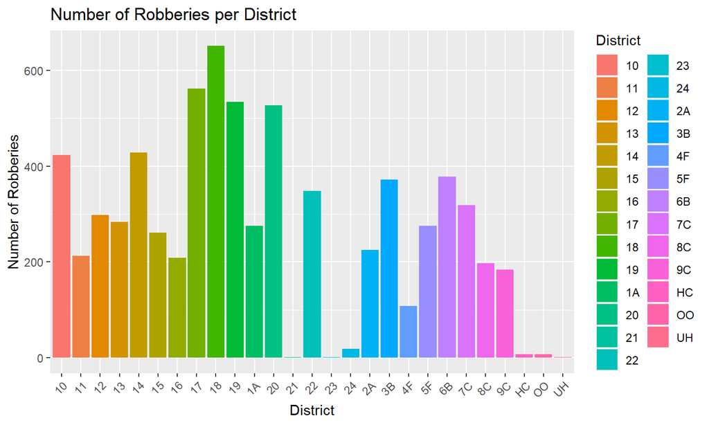

## Incidents by premise

```
## # A tibble: 45 × 2
##    Premise                              IncidentCount
##    <chr>                                        <int>
##  1 Residence, Home (Includes Apartment)         88454
##  2 Parking Lot, Garage                          49493
##  3 Highway, Road, Street, Alley                 37923
##  4 Other, Unknown                                9998
##  5 Convenience Store                             7202
##  6 Department, Discount Store                    6682
##  7 Commercial, Office Building                   6517
##  8 Restaurant                                    6025
##  9 Service, Gas Station                          5629
## 10 Hotel, Motel, ETC                             5356
## # ℹ 35 more rows
```

## Incidents distribution per hour

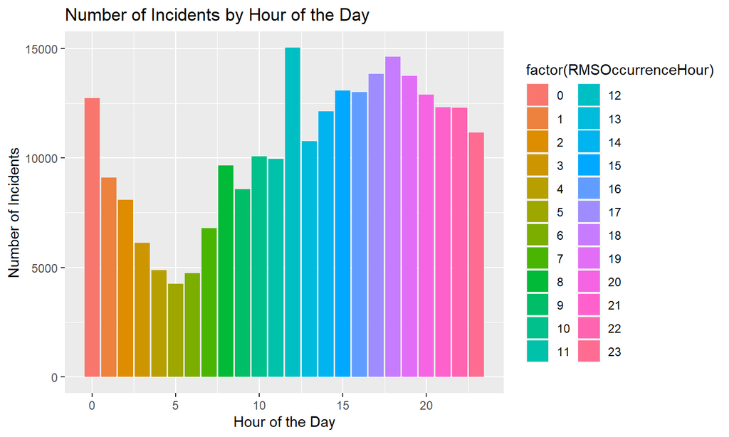

## Heat map per District & Hour

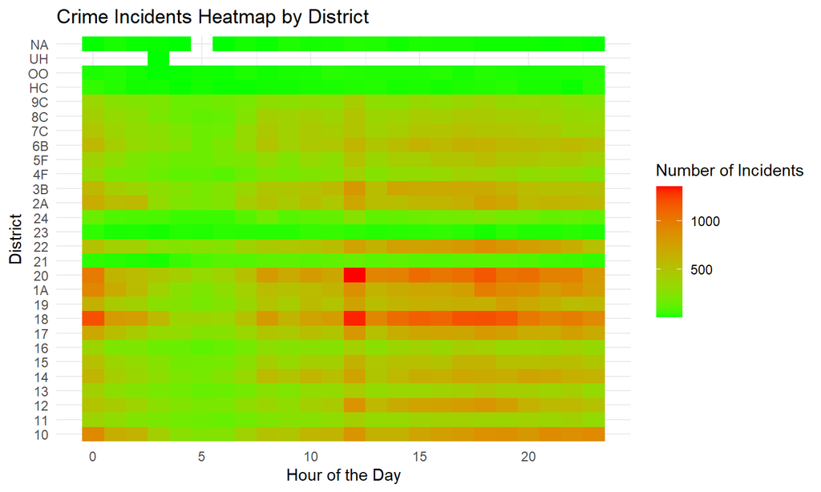